# Diabetes Prediction Using Survey Data

Wendy Deng

Ruolan Li

Kira Nightingale

# 1 Executive Summary

There are approximately 37.3 million individuals in the US living with diabetes, which represents 11.3% of the population. It is estimated that around 8.5 million of these individuals remain undiagnosed, meaning that 23% of adults living with diabetes are unaware of their health status (1). Diabetes is associated with significant morbidity and mortality, with diabetic individuals at risk of additional health conditions including chronic kidney disease, heart disease, nerve damage, vision loss, and difficulties with wound healing (2). Studies have estimated that diabetes may be present in an individual 4-7 years before the onset of clinical signs, highlighting the importance of routine screening even when patients remain asymptomatic (3-5). This is especially important given that clinical outcomes are improved with early intervention (6). Unfortunately, a high proportion of US adults do not attend routine health screenings, with one study finding that only 46.2% of individuals who met American Diabetes Association screening criteria had received diabetes screening (7). Prior studies have identified numerous barriers to health screenings, including lack of knowledge of the condition, fear, and lack of access to screening services (8). It could therefore be beneficial to create a non-invasive, survey-based questionnaire that can be completed by a patient at home which would identify their likelihood of having diabetes. Such a tool could eliminate some barriers to screening access by improving convenience as well as eliminate some of the fear associated with attending screening procedures in a clinical setting. Individuals who are likely to have diabetes based on the survey results would be prompted to receive screening and provided with resources and information to help encourage completion of screening.

In this study, we sought to use existing health survey data from the CDC’s Behavioral Risk Factor Surveillance System (BRFSS) to create a model which would predict whether an individual has diabetes with a high level of accuracy. The BRFSS is a national telephone-based survey collected in all states and US territories. We selected the 2019 dataset as it was the most recent pre-pandemic. The original file included 342 variables and 418,268 observations.After data cleaning, including generation of new variables, removal of variables with a high proportion of missingness, and single imputation for variables with a small amount of missingness. The final analytic dataset included 253,684 observations and 58 variables. The data was examined descriptively, and principal component analysis was performed. For the predictive model, we generated models using LASSO, neural network, random forest, and ensemble methods. The models were compared using misclassification error as an assessment criteria, and the ensemble model was selected as the best model with a misclassification error of only 12.3%.

In this project, we were able to successfully create a model which predicts a person’s likelihood of having diabetes with a relatively small misclassification error. A model such as this could be used as a low-intensity and low-stress preliminary screener for patients who might be concerned about their diabetes risk but who, for whatever reason, are hesitant to receive clinical testing. Ideally, individuals who are flagged as having a high likelihood of diabetes could be presented with resources and encouraged to attend in-person testing for confirmation. Although a model such as this shows promise, it is subject to limitations including potential issues with the underlying dataset (missing data, self-report bias, and social desirability bias) as well as imperfect prediction. Further projects should focus on tuning the cut-off threshold, balancing the health risk associated with false negatives with the mental harm associated with false positives.

# 2 Background

There are approximately 37.3 million individuals in the US living with diabetes, which represents 11.3% of the population. It is estimated that around 8.5 million of these individuals remain undiagnosed, meaning that 23% of adults living with diabetes are unaware of their health status (1). Diabetes is associated with significant morbidity and mortality, with diabetic individuals at risk of additional health conditions including chronic kidney disease, heart disease, nerve damage, vision loss, and difficulties with wound healing (2). Studies have estimated that diabetes may be present in an individual 4-7 years before the onset of clinical signs, highlighting the importance of routine screening even when patients remain asymptomatic (3-5). This is especially important given that clinical outcomes are improved with early intervention (6). Unfortunately, a high proportion of US adults do not attend routine health screenings, with one study finding that only 46.2% of individuals who met American Diabetes Association screening criteria had received diabetes screening (7). Prior studies have identified numerous barriers to health screenings, including lack of knowledge of the condition, fear, and lack of access to screening services (8). It could therefore be beneficial to create a non-invasive, survey-based questionnaire that can be completed by a patient at home which would identify their likelihood of having diabetes. Such a tool could eliminate some barriers to screening access by improving convenience as well as eliminate some of the fear associated with attending screening procedures in a clinical setting. Individuals who are likely to have diabetes based on the survey results would be prompted to receive screening and provided with resources and information to help encourage completion of screening.

In this study, we sought to use existing health survey data from the CDC’s Behavioral Risk Factor Surveillance System (BRFSS) to create a model which would predict whether an individual has diabetes with a high level of accuracy.

# 3 Methods

## 3.1 Data Cleaning

Data for this project was obtained from the CDC’s 2019 BRFSS. The BRFSS is a national telephone-based survey which is conducted in all 50 states plus Puerto Rico and Guam, and collects information from US adults regarding health risk factors, medical conditions, and use of preventive services. For this project, we elected to use data from the 2019 survey given concern that the wide-reaching impact of the COVID-19 pandemic on health and socioeconomic factors would influence the analysis.

The complete 2019 BRFSS file was downloaded from the CDC’s website. The original file included 342 variables and 418,268 observations. First, we selected variables which could plausibly be used to predict the presence of diabetes. We then eliminated responses from individuals living in Puerto Rico or Guam to limit our analysis to US states only. Categorical variables were re-coded from numeric to character for ease of interpretation. The BRFSS survey includes many questions with skip logic; for example, if a respondent reports being of the male sex, they will not be asked about Pap smear or mammography history. Within the dataset, these values as coded as missing; we therefore generated new variables which included “not applicable” as an option to distinguish these values from true missing values. Finally, we generated a new variable for drinks of alcohol per month based on respondents’ stated drinking instances per week/month and average number of drinks per instance.

Because different survey modules are used in different states, some variables exhibited a high rate of missingness. For example, as can be seen in **Figure 1**, greater than 90% of participants are missing responses for questions relating to skin cancer risk, food stamp use, and diagnosis with hepatitis B or C.

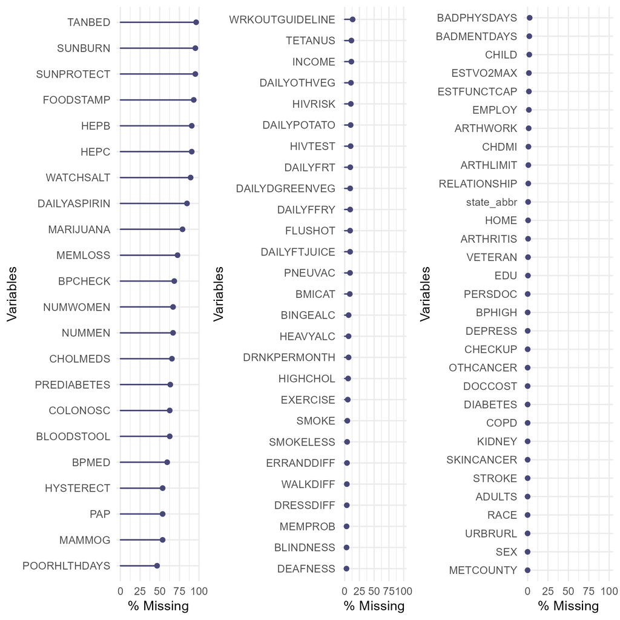

Figure 1. Percent missingness of data points prior to additional cleaning.

## 3.2 Analysis

First, the data was examined descriptively. Next, principal component analysis (PCA) was performed using the six numeric variables which describe daily diet. Based on an assessment of scree plots of variances and the proportion of variance explained (PVE), it was determined that an assessment using four leading principal components (PCs) would be sufficient. Principal components were visually examined through the generation of biplots and the PCs were further explored through interpretation of the loadings. K-means clustering was then performed using the 12 numeric variables in the dataset. We first performed PCA and used 8 PCs for further analysis based on the summary table and the scree plot of PVE. To determine the number of clusters, we calculated the total within-cluster sum of square (WSS).

# 4 Results

## 4.1 Descriptive Statistics

The final analytic dataset includes 58 variables with 253,684 observations and no missing data. **Figure 2** provides a density map of the number of respondents per state - it is evident that the respondent distribution does not match the US population, as California has relatively few respondents whereas Nebraska has very many. The BRFSS data includes weighting variables which can be used to ensure the responses are representative of the US population, which is necessary to draw many epidemiological conclusions. However, as our goal is prediction, it is not necessary to employ the survey weights.

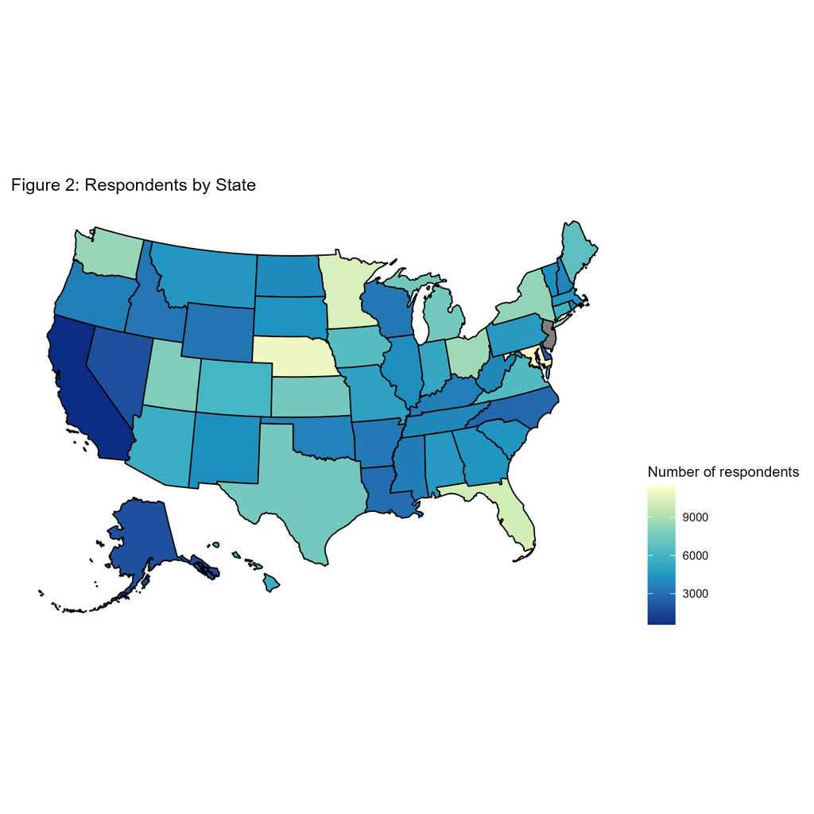

**Figure 3** shows the distribution of respondent race and ethnicity by sex. The majority of the study population is non-Hispanic white, and there are generally equal numbers of males and females. Survey participants were asked about their overall physical and mental health, reporting the number of days within the past 30 that they experienced poor mental or physical health. In Figure 4, we can see that most participants felt that they experienced 0 to few poor mental or physical health days in the past month, with a subset of participants reporting poor health in all of the past 30 days.

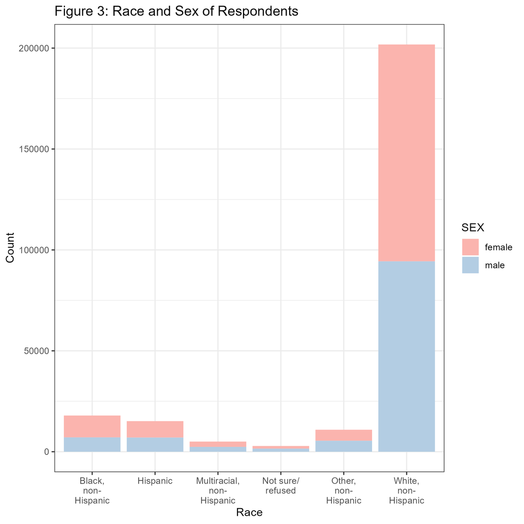

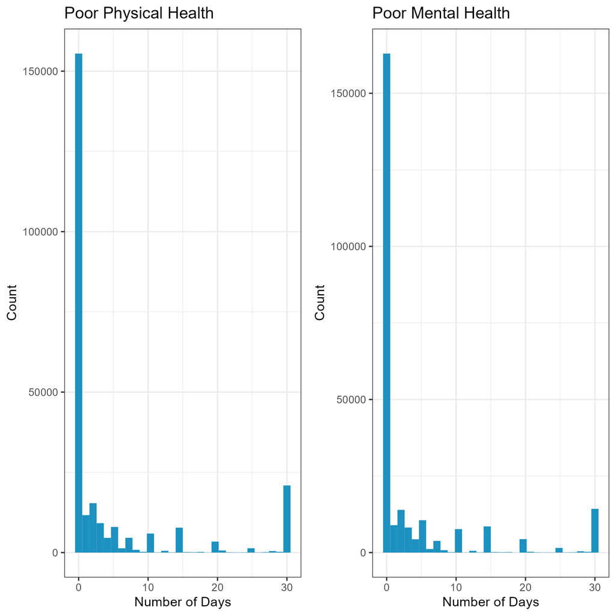

Figure 4: Number of reported poor physical and mental health days during the past 30 days.

The interactive treemap in **Figure 5** shows the relative number of respondents in each education category. Information on employment status and housing status can be explored within each education level by clicking on the respective rectangle. The majority of respondents completed at least some college. There appears to be a correlation between level of education and employment status, with individuals who attained higher levels of education being less likely to be unemployed than individuals who attained lower levels of education. Similarly, individuals who are employed or retired are more likely to own their home than individuals who are unemployed.

**Figure 5:** Interactive treemap of housing status by employment status and education level

[interactive chart not shown]

Finally, we examine the distribution of characteristics by presence of diabetes, the outcome that we aim to predict (**Table 1**). Many of the selected variables are significantly different at the 0.05 level between the diabetic and non-diabetic groups. Individuals with diabetes are more likely to be Black or Hispanic, unemployed/unable to work, attain lower levels of education, have other co-morbid conditions such as high blood pressure and obesity, and eat fewer servings of fruits and vegetables.

Table 1: Selected descriptive statistics of the study population by diabetes diagnosis.

|  | Diabetes (N=36214) | No Diabetes (N=217470) | P-value |
| --- | --- | --- | --- |
| Sex |  |  |  |
| female | 18326 (50.6%) | 117472 (54.0%) | <0.001 |
| male | 17888 (49.4%) | 99998 (46.0%) |  |
| Race |  |  |  |
| Black, non-Hispanic | 3982 (11.0%) | 13959 (6.4%) | <0.001 |
| Hispanic | 2258 (6.2%) | 12912 (5.9%) |  |
| Multiracial, non-Hispanic | 785 (2.2%) | 4246 (2.0%) |  |
| Not sure/refused | 469 (1.3%) | 2377 (1.1%) |  |
| Other, non-Hispanic | 1832 (5.1%) | 9067 (4.2%) |  |
| White, non-Hispanic | 26888 (74.2%) | 174909 (80.4%) |  |
| Education |  |  |  |
| College or more | 10676 (29.5%) | 92533 (42.5%) | <0.001 |
| Elementary | 1145 (3.2%) | 2894 (1.3%) |  |
| High school/GED | 11210 (31.0%) | 53227 (24.5%) |  |
| None | 32 (0.1%) | 133 (0.1%) |  |
| Some college | 10831 (29.9%) | 60936 (28.0%) |  |
| Some high school | 2320 (6.4%) | 7747 (3.6%) |  |
| Living Arrangement |  |  |  |
| Not sure | 33 (0.1%) | 258 (0.1%) | <0.001 |
| Other | 1426 (3.9%) | 9468 (4.4%) |  |
| Own | 26610 (73.5%) | 160684 (73.9%) |  |
| Rent | 8145 (22.5%) | 47060 (21.6%) |  |
| Employment Status |  |  |  |
| Employed | 8867 (24.5%) | 97591 (44.9%) | <0.001 |
| Homemaker | 1236 (3.4%) | 9580 (4.4%) |  |
| Retired | 17062 (47.1%) | 63274 (29.1%) |  |
| Self-employed | 1984 (5.5%) | 21129 (9.7%) |  |
| Student | 125 (0.3%) | 5743 (2.6%) |  |
| Unable to work | 5697 (15.7%) | 12442 (5.7%) |  |
| Unemployed 1 year or more | 756 (2.1%) | 3526 (1.6%) |  |
| Unemployed less than 1 year | 487 (1.3%) | 4185 (1.9%) |  |
| Timing of Most Recent Health Check-up |  |  |  |
| 5 or more years ago | 268 (0.7%) | 8901 (4.1%) | <0.001 |
| Never | 56 (0.2%) | 705 (0.3%) |  |
| Not sure | 140 (0.4%) | 1569 (0.7%) |  |
| Past 2 years | 1085 (3.0%) | 22091 (10.2%) |  |
| Past 5 years | 370 (1.0%) | 11084 (5.1%) |  |
| Past year | 34295 (94.7%) | 173120 (79.6%) |  |
| High Blood Pressure |  |  |  |
| During pregnancy only | 128 (0.4%) | 1724 (0.8%) | <0.001 |
| No | 8838 (24.4%) | 133248 (61.3%) |  |
| Not sure | 59 (0.2%) | 339 (0.2%) |  |
| Pre-hypertensive | 254 (0.7%) | 2491 (1.1%) |  |
| Yes | 26935 (74.4%) | 79668 (36.6%) |  |
| Depression |  |  |  |
| No | 26765 (73.9%) | 174997 (80.5%) | <0.001 |
| Not sure | 125 (0.3%) | 645 (0.3%) |  |
| Yes | 9324 (25.7%) | 41828 (19.2%) |  |
| BMI Category |  |  |  |
| Normal | 4711 (13.0%) | 68782 (31.6%) | <0.001 |
| Obese | 20192 (55.8%) | 65569 (30.2%) |  |
| Overweight | 11099 (30.6%) | 79435 (36.5%) |  |
| Underweight | 212 (0.6%) | 3684 (1.7%) |  |
| Workout Recommendations Met |  |  |  |
| Aerobic guidelines met | 9686 (26.7%) | 66745 (30.7%) | <0.001 |
| Neither guideline met | 16739 (46.2%) | 72045 (33.1%) |  |
| Strength and aerobic guidelines met | 5778 (16.0%) | 54550 (25.1%) |  |
| Strength guidelines met | 4011 (11.1%) | 24130 (11.1%) |  |
| Daily Servings of Dark Green Vegetables |  |  |  |
| Mean (SD) | 0.539 (1.07) | 0.616 (1.25) | <0.001 |
| Median [Min, Max] | 0.400 [0, 60.0] | 0.430 [0, 92.0] |  |
| Daily Servings of Other Vegetables |  |  |  |
| Mean (SD) | 0.890 (1.09) | 0.963 (1.22) | <0.001 |
| Median [Min, Max] | 0.830 [0, 30.0] | 1.00 [0, 80.0] |  |
| Daily Servings of Fruit |  |  |  |
| Mean (SD) | 1.04 (1.02) | 1.11 (1.19) | <0.001 |
| Median [Min, Max] | 1.00 [0, 15.0] | 1.00 [0, 88.0] |  |
| Daily Servings of French Fries |  |  |  |
| Mean (SD) | 0.212 (0.481) | 0.217 (0.552) | 0.12 |
| Median [Min, Max] | 0.140 [0, 30.0] | 0.140 [0, 91.0] |  |
| Daily Servings of Potatoes |  |  |  |
| Mean (SD) | 0.243 (0.586) | 0.247 (0.567) | 0.203 |
| Median [Min, Max] | 0.140 [0, 32.0] | 0.140 [0, 75.0] |  |
| Number of Alcoholic Drinks per Month |  |  |  |
| Mean (SD) | 6.76 (33.7) | 14.0 (45.8) | <0.001 |
| Median [Min, Max] | 0 [0, 2100] | 1.00 [0, 2640] |  |

## 4.2 Principal Component Analysis

For the principal component analysis, we focus on six numeric variables measuring the daily diet.

- `DAILYFTJUICE`: Daily servings of juice
- `DAILYDGREENVEG`: Daily servings of dark green vegetables
- `DAILYFFRY`: Daily servings of French fries
- `DAILYPOTATO`: Daily servings of potatoes
- `DAILYFRT`: Daily servings of fruit
- `DAILYOTHVEG`: Daily servings of other vegetables

**Table 2.1** shows the loadings of all six PCs. We can observe the PVE and cumulative PVE from **Figure 6.1**, **Figure 6.2** and **Table 2.2**. The scree plots of variances and PVE indicate that the four leading PCs should be sufficient. We further explore the interpretations of loadings and PCs:
$$\begin{align*}
PC_1 = 0.291 \times DAILYFTJUICE + 0.530 \times DAILYDGREENVEG + 0.275
\times DAILYFFRY \\ + 0.384 \times DAILYPOTATO + 0.320 \times DAILYFRT +
0.555 \times DAILYOTHVEG \\
PC_2 = -0.005 \times DAILYFTJUICE + 0.243 \times DAILYDGREENVEG -0.671
\times DAILYFFRY \\ -0.534 \times DAILYPOTATO + 0.375 \times DAILYFRT +
0.256 \times DAILYOTHVEG \\
PC_3 = 0.770 \times DAILYFTJUICE -0.340 \times DAILYDGREENVEG + 0.002
\times DAILYFFRY \\ -0.012 \times DAILYPOTATO + 0.434 \times DAILYFRT
-0.321 \times DAILYOTHVEG \\
PC_4 = -0.562 \times DAILYFTJUICE -0.285 \times DAILYDGREENVEG + 0.176
\times DAILYFFRY \\ + 0.150 \times DAILYPOTATO + 0.739 \times DAILYFRT
-0.051 \times DAILYOTHVEG \\
\end{align*}$$

- $PC_1$: $PC_1$ is approximately proportional to the total of the six daily diet intake variables (`DAILYFTJUICE`, `DAILYFFRY`, `DAILYPOTATO`, `DAILYDGREENVEG`, `DAILYFRT`, and `DAILYOTHVEG)`, indicating that higher values of $PC_1$ correspond to a higher total daily diet intake. Therefore, $PC_1$ can be interpreted as measuring overall diet intake.
- $PC_2$: The sign of the loadings is negative for `DAILYFTJUICE`, `DAILYFFRY`, and `DAILYPOTATO`, indicating that a higher intake of these foods is associated with a less healthy diet. Conversely, the sign of the loadings is positive for `DAILYDGREENVEG`, `DAILYFRT`, and `DAILYOTHVEG`, indicating that a higher intake of these foods is associated with a healthier diet. Therefore, $PC_2$ can be interpreted as measuring the difference between the intake of healthy and less healthy foods.”
- $PC_3$: The sign of the loadings is positive for `DAILYFTJUICE` and `DAILYFRT`, indicating that higher intake of these foods is associated with $PC_3$. Conversely, the sign of the loadings is negative for `DAILYDGREENVEG`, `DAILYPOTATO`, and `DAILYOTHVEG`, indicating that a higher intake of these foods is associated with lower values of $PC_3$. Therefore, $PC_3$ represents the difference between the intake of fruits and the intake of vegetables. Since the loading for `DAILYFFRY` is only 0.002, we can ignore this variable in $PC_3$.
- $PC_4$: The sign of the loadings is positive for `DAILYFFRY`, `DAILYPOTATO` and `DAILYFRT`, while the sign is negative for `DAILYFTJUICE`, `DAILYDGREENVEG` and `DAILYOTHVEG`. While there is no direct interpretation for $PC_4$ compared to other PCs, some studies suggest that fruit and fruit juice can affect blood sugar levels. Therefore, we hypothesize that $PC_4$ represents the difference between a diet higher in fructose and carbon, and a diet higher in sugar and fiber.

Table 2.1: Summary table of PCs and loadings

|  | PC1 | PC2 | PC3 | PC4 | PC5 | PC6 |
| --- | --- | --- | --- | --- | --- | --- |
| DAILYFTJUICE | 0.291 | -0.005 | 0.770 | -0.562 | -0.008 | 0.082 |
| DAILYDGREENVEG | 0.530 | 0.243 | -0.340 | -0.285 | -0.213 | -0.646 |
| DAILYFFRY | 0.275 | -0.671 | 0.002 | 0.176 | -0.656 | 0.112 |
| DAILYPOTATO | 0.384 | -0.534 | -0.012 | 0.150 | 0.716 | -0.182 |
| DAILYFRT | 0.320 | 0.375 | 0.434 | 0.739 | -0.072 | -0.127 |
| DAILYOTHVEG | 0.555 | 0.256 | -0.321 | -0.051 | 0.080 | 0.717 |

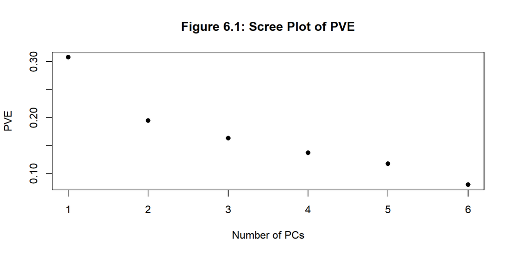

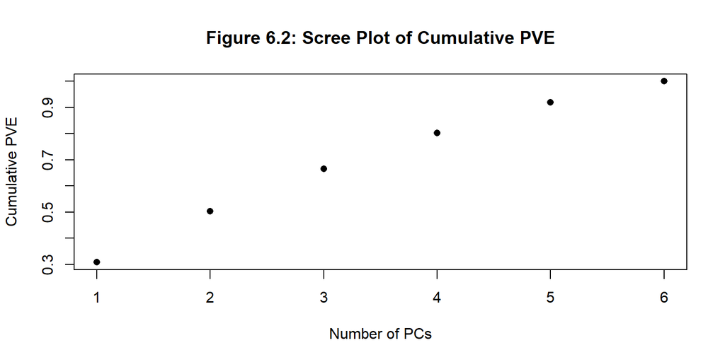

Table 2.2: Summary table of PVE

|  | PC1 | PC2 | PC3 | PC4 | PC5 | PC6 |
| --- | --- | --- | --- | --- | --- | --- |
| Standard deviation | 1.359 | 1.080 | 0.989 | 0.908 | 0.839 | 0.692 |
| Proportion of Variance | 0.308 | 0.194 | 0.163 | 0.137 | 0.117 | 0.080 |
| Cumulative Proportion | 0.308 | 0.502 | 0.665 | 0.803 | 0.920 | 1.000 |

The biplot (Figure 7) visualizes the PC scores together with the loadings of the original six variables. From the plot, we can see that the loadings for $PC_1$ have the same signs, while $PC_2$ captures the difference between the total intake of`DAILYDGREENVEG`, `DAILYFRT`, `DAILYOTHVEG` and `DAILYFTJUICE` versus`DAILYFTJUICE`, `DAILYFFRY`, and `DAILYPOTATO`.

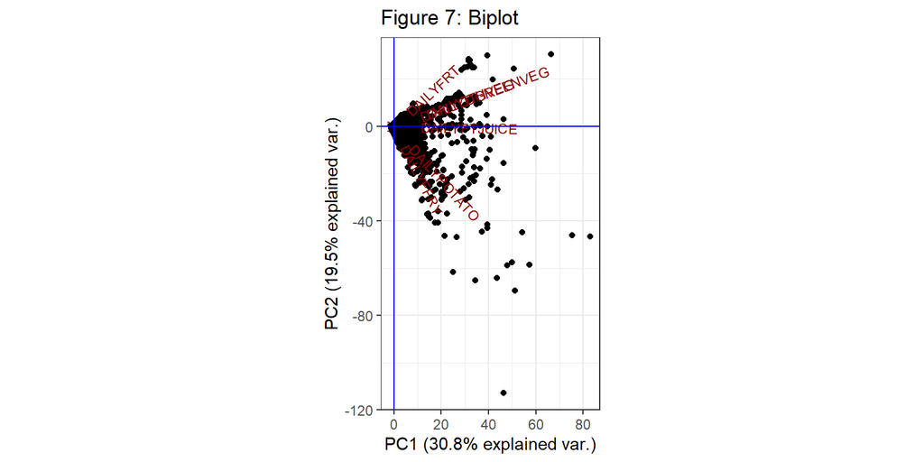

## 4.3 K-means Clustering

We chose 12 numeric variables for clustering. We first performed PCA and used 8 PCs for further analysis based on the summary table (**Table 3**) and the scree plot of PVE (**Figure 8**). To determine the number of clusters, we calculated the total within-cluster sum of square (WSS) and decided to use 4 clusters (**Figure 9**). The figure “True Diabetes Status VS Clusters” shows the comparison of the real diabetes status with the clustering by k-means (**Figure 10**). **We cannot observe a clear pattern, indicating that we cannot use only the numeric variables to separate the diabetes status clearly.**

Table 3: Summary table of PVE for clustering

|  | PC1 | PC2 | PC3 | PC4 | PC5 | PC6 | PC7 | PC8 | PC9 | PC10 | PC11 | PC12 |
| --- | --- | --- | --- | --- | --- | --- | --- | --- | --- | --- | --- | --- |
| Standard deviation | 1.514 | 1.359 | 1.166 | 1.070 | 1.000 | 0.988 | 0.907 | 0.875 | 0.833 | 0.788 | 0.691 | 0.001 |
| Proportion of Variance | 0.191 | 0.154 | 0.113 | 0.095 | 0.083 | 0.081 | 0.069 | 0.064 | 0.058 | 0.052 | 0.040 | 0.000 |
| Cumulative Proportion | 0.191 | 0.345 | 0.458 | 0.554 | 0.637 | 0.718 | 0.787 | 0.851 | 0.908 | 0.960 | 1.000 | 1.000 |

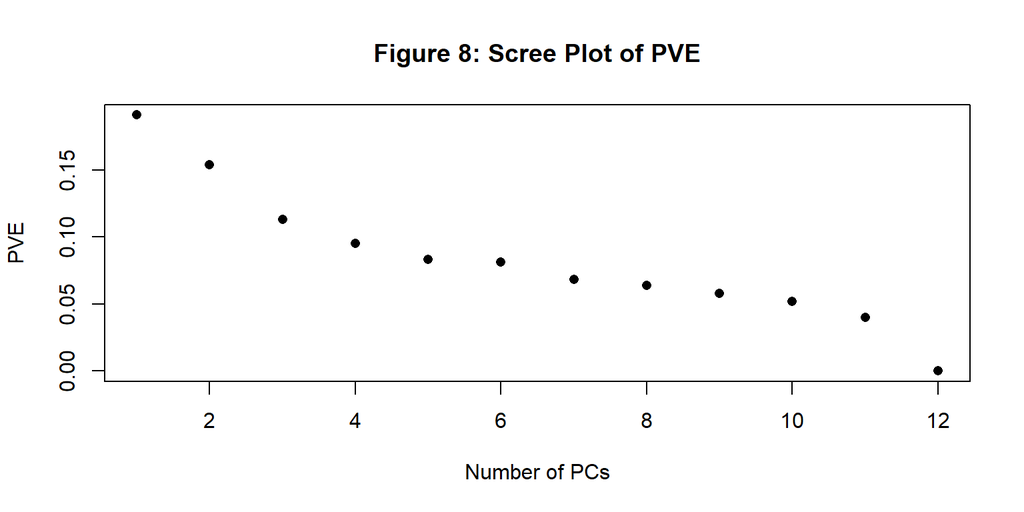

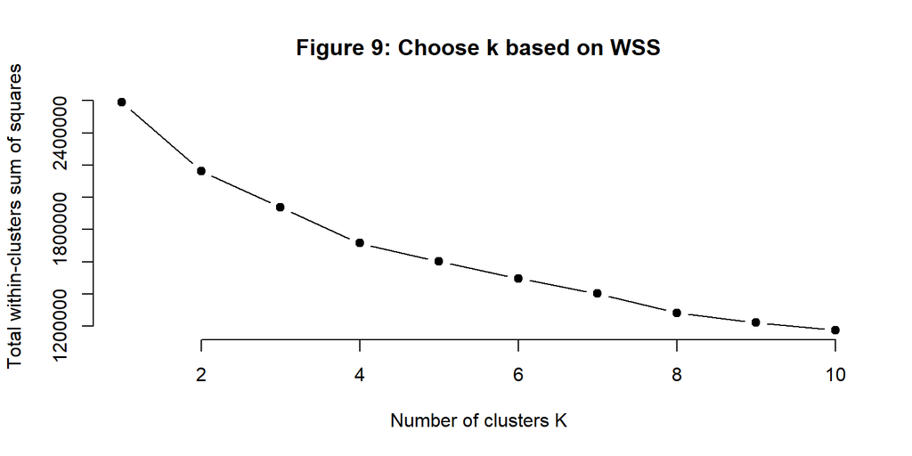

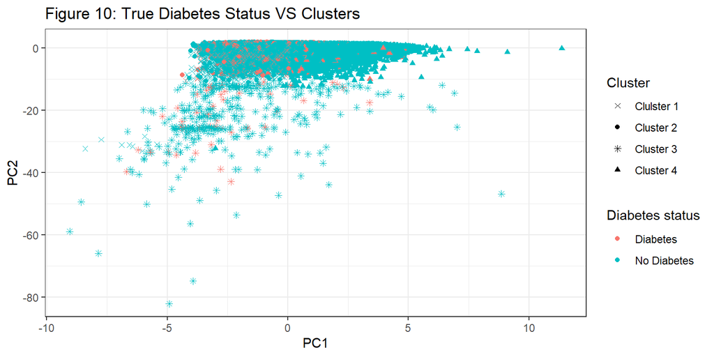

## 4.4 LASSO

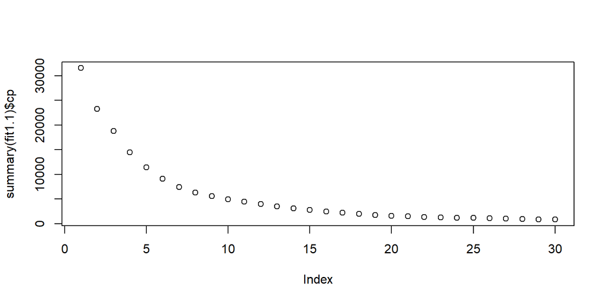

## 4.5 Random Forest

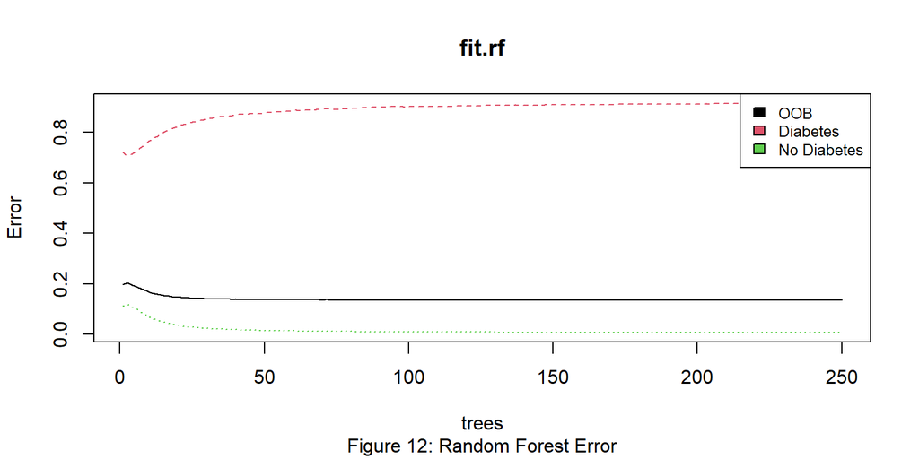

[figure not shown]

## 4.6 Ensemble Model

Finally, we created an ensemble model by taking the average prediction of all three models. This resulted in a final validation error of 12.3%, the best of all models created.

# 5 Conclusion

Using the methods described above, we were able to successfully create a model which predicted diabetes using survey data with an error of 12.3%. With further refinement, a similar model such as ours could be used as an online diabetes screener. This low-effort, low-stress method of screening for potential diabetes could be used by individuals at home, and those who are likely to have diabetes would be referred to their clinician for testing. This may take some of the burden and fear away from patients, ideally funneling those who most need screening into appropriate testing centers.

Unfortunately, our model is subject to limitations. First, we used single imputation for missing data rather than multiple imputation, which has the potential to be more accurate. Second, the analysis is based on survey data which is subject to recall and social desirability bias. In some ways, this matters less than in other contexts because the end goal was to develop a model which could be used to process future survey data. However, if the data that the model was built upon was inaccurate then the model itself would be as well. In addition, many questions in this survey involve asking the respondent whether a doctor has ever told them that they have a certain medical condition. We could expect that individuals who have recently been diagnosed with, for example, heart disease, would also have been tested for diabetes. In this way, the model assumes, to an extent, that the individual must be aware of their health status for many conditions except for diabetes. However, it should be noted that the original data set included options for “not sure” and these were built into the model. Finally, the cutoff threshold that we used in this project was 0.5, meaning that anyone with a predicted value above this threshold was predicted ot have diabetes and anyone below was predicted not to have diabetes. Future projects should assess this threshold to determine if something other than 0.5 would be better in practice. This is a key consideration, as there are clear health risks associated with false negatives but potential mental harm could result from false positives.

Ultimately, a tool such as this has promise as a low-intensity health screener, but would need additional refinement and testing before being released to the public.

# 6 References

1. Centers for Disease Control and Prevention. National Diabetes Statistics Report website. https://www.cdc.gov/diabetes/data/statistics-report/index.html. Accessed April 16, 2023.
2. Centers for Disease Control and Prevention. Prevent Diabetes Complications. https://www.cdc.gov/diabetes/managing/problems.html. Accessed April 16, 2023.
3. Porta M, Curletto G, CipulloS , et. al. Estimating the Delay Between Onset and Diagnosis of Type 2 Diabetes From the Time Course of Retinopathy Prevalence. Diabetes Care 1 June 2014; 37 (6): 1668–1674.
4. Harris MI, Klein R, Welborn TA, Knuiman MW. Onset of NIDDM occurs at least 4-7 yr before clinical diagnosis. Diabetes Care. 1992;15:815–819
5. Ellis JD, Zvandasara T, Leese G, et al. DARTS/MEMO Collaboration. Clues to duration of undiagnosed disease from retinopathy and maculopathy at diagnosis in type 2 diabetes: a cross-sectional study. Br J Ophthalmol 2011;95:1229–1233
6. Harris MI and Eastman RC (2000), Early detection of undiagnosed diabetes mellitus: a US perspective. Diabetes Metab. Res. Rev., 16: 230-236.
7. Kiefer MM, Silverman JB, Young BA, Nelson KM. National patterns in diabetes screening: data from the National Health and Nutrition Examination Survey (NHANES) 2005-2012. J Gen Intern Med. 2015 May;30(5):612-8. doi: 10.1007/s11606-014-3147-8. Epub 2014 Dec 23.
8. Le Bonniec A, Sun S, Andrin A, et al. Barriers and Facilitators to Participation in Health Screening: an Umbrella Review Across Conditions. Prev Sci 23, 1115–1142 (2022).